# Untitled

Dan Mungas

2024-08-29

## Background

- Simulating cognitive change across the older adult life span
  - Simulation studies of cognitive trajectories in older adults have potential to expand knowledge about methods for detecting cognitive decline and even for understanding cognitive decline and associated risk and protective factors
  - Reality based simulation of the variability of cognitive trajectories in the older adult population is a critical element for meaningful simulation studies
  - Overarching goal of this effort was to demonstrate and evaluate feasability of a specific approach to simulating cognitive trajectories based upon empirical results from a real-world sample

## Methods

- Sample
  - Merged longitudinal sample comprised of 4 longitudinal cohort studies with shared longitudinal cognitive assessment protocols
    - UC Davis Alzheimer’ Disease Research Center longitudinal cohort (ADRC)
    - Kaiser Healthy Aging and Diverse Life Experiences study (KHANDLE)
    - Kaiser Study of Healthy Aging in African Americans (STAR)
    - Kaiser Life After 90 Study (LA90)
    - Sample characteristics
      - ADRC, KHANDLE, and LA90 are composed of demographically diverse older adults (race/ethnicity, education, age, gender, language), STAR is an African American sample. The merged sample is demographically diverse and representative of community dwelling older aduls in Northern California.
      - sub-samples are composed of largely community dwelling older adults recruited to represent the range of cognitive function in the older adult population
      - there is a diversity of cognitive trajectories in all sub-samples
        - >50% cognitively normal, >40% cognitively impaired (MCI or dementia)
      - longitudinal assessment protocols in all studies that use the same cognitive assessment instruments
- Cognitive Assessment
  - Spanish and English Neuropsychological Assessment Scales (SENAS)
    - Neuropsychological test battery developed and validated for assessment of cognition in demographically diverse older adults
      - Emphasis on high measurement precision (information, reliability) across a broad range of ability spanning ~ ± 2 SD in the older adult population
      - Measures employed in this study account for differential item function across race/ethnic/language groups
    - Measures used
      - Verbal episodic memory (primary measure)
        - Based on a word list learning test utilizing a 15-word list, 5 learning trials, and a delayed free recall trial after distraction
        - Scored using item response theory methods - trial and delayed recalltrials modeled as ordinal items
      - Executive function (secondary measure)
        - composite of category fluency, phonemic/letter fluency, working memory
          - category fluency - 60 second trials to name animals, fruits, vegetables
          - phonemic/letter fluency - 60 second trials to name words starting with F and L sounds
          - working memory - digit span backward (strings of digits repeated backwards), list sorting (lists of animals and/or fruits repeated in ordere of increasing size)
        - Scored using item response theory methods applied to ordinal items
- Data Analysis
  - Mixed effects modeling overview
    - Mixed effects modeling of longitudinal data
      - orthogonal polynomial decomposition of time variable to evaluate non-linear time trends
        - quadratic polynomial model compared with linear
      - alternate time indices
        - time in study (+ baseline age)
          - separates within-person time in study effects and between-person age at baseline effects
        - age
          - within and between person effects are confounded
  - Mixed effects modeling details
    - Mixed effects modeling
      - Bayesian modeling platform (R brms package)
        - random effects for person, person-x-time, person-x-time^2
    - Polynomial decomposition
      - orthogonal decomposition of time variable using R stats::poly
      - orthogonal components rescales to original time variable (in years) to facilitate interpretability
        - orthogonality maintained after rescaling
  - Simulation of cognitive trajectories overview
    - Estimated model object from mixed effects analysis of empirical data used to predict outcome based on new data
  - Simulation of cognitive trajectories details
    - Step 1 - perform orthogonal polynomial decomposition of time variable in empirical dataset
      - rescale orthogonal polynomials to years and years^2 metrics
    - Step 2 - estimate empirical mixed effects model using rescales orthogonal time components
    - Step 3 - simulate outcome variable responses using fitted empirical model object
      - create or identify new dataset with synthetic of empirical data for time and baseline age
      - use stats::poly() fitted model object to create orthogonal polynomial time components, rescale as for original empirical file
      - use brms::posterior_predict to simulate outcome responses in new dataset

## Results

### Longitudinal Models

#### Quadratic versus linear model comparison

Time in study - quadratic versus linear time (negative value for fit1 corresponds to worse fit of linear model)

```
##      elpd_diff se_diff
## fit2   0.0       0.0
## fit1 -51.2       8.0
```

Time in study - quadratic time, quadratic versus linear baseline age (negative value for fit2 corresponds to worse fit of quadratic baseline age model)

```
##      elpd_diff se_diff
## fit1  0.0       0.0
## fit2 -4.0       3.5
```

Age - quadratic versus linear model (negative value for fit1 corresponds to worse fit of linear model)

```
##      elpd_diff se_diff
## fit2    0.0       0.0
## fit1 -166.7      14.5
```

#### Estimated models

Time in study modeled as quadratic polynomial

```
##  Family: gaussian
##   Links: mu = identity; sigma = identity
## Formula: vrmem ~ timep1s + timep2s + preval1 + preval2 + agebl_75 + timep1s:agebl_75 + timep2s:agebl_75 + (1 + timep1s + timep2s | id)
##    Data: df1 (Number of observations: 14284)
##   Draws: 4 chains, each with iter = 2000; warmup = 1000; thin = 1;
##          total post-warmup draws = 4000
##
## Group-Level Effects:
## ~id (Number of levels: 3700)
##                        Estimate Est.Error l-95% CI u-95% CI   Rhat Bulk_ESS
## sd(Intercept)            0.7507    0.0106   0.7305   0.7713 1.0011     1276
## sd(timep1s)              0.0605    0.0046   0.0516   0.0699 1.0122      597
## sd(timep2s)              0.0023    0.0004   0.0014   0.0032 1.0128      393
## cor(Intercept,timep1s)   0.1917    0.0644   0.0651   0.3191 1.0001     2079
## cor(Intercept,timep2s)  -0.6459    0.1347  -0.9231  -0.3954 1.0119      383
## cor(timep1s,timep2s)    -0.3583    0.1470  -0.6290  -0.0476 1.0019     1137
##                        Tail_ESS
## sd(Intercept)              2038
## sd(timep1s)                1359
## sd(timep2s)                 896
## cor(Intercept,timep1s)     2698
## cor(Intercept,timep2s)      503
## cor(timep1s,timep2s)       1983
##
## Population-Level Effects:
##                  Estimate Est.Error l-95% CI u-95% CI   Rhat Bulk_ESS Tail_ESS
## Intercept         -0.1915    0.0215  -0.2320  -0.1492 1.0031     1701     2966
## timep1s           -0.0851    0.0048  -0.0944  -0.0757 0.9999     3892     2934
## timep2s            0.0002    0.0004  -0.0006   0.0010 1.0026     3233     2848
## preval1            0.1000    0.0167   0.0675   0.1329 1.0018     5323     3328
## preval2            0.0151    0.0164  -0.0168   0.0463 1.0013     6189     3268
## agebl_75          -0.0436    0.0014  -0.0464  -0.0409 1.0052     1058     1981
## timep1s:agebl_75  -0.0027    0.0005  -0.0037  -0.0016 1.0037     4424     3215
## timep2s:agebl_75  -0.0001    0.0000  -0.0002  -0.0000 1.0002     4114     2652
##
## Family Specific Parameters:
##       Estimate Est.Error l-95% CI u-95% CI   Rhat Bulk_ESS Tail_ESS
## sigma   0.5117    0.0041   0.5037   0.5198 1.0008     1927     2785
##
## Draws were sampled using sampling(NUTS). For each parameter, Bulk_ESS
## and Tail_ESS are effective sample size measures, and Rhat is the potential
## scale reduction factor on split chains (at convergence, Rhat = 1).
```

Time in study modeled as quadratic polynomial, baseline age modeled as quadratic polynomial

```
##  Family: gaussian
##   Links: mu = identity; sigma = identity
## Formula: vrmem ~ timep1s + timep2s + preval1 + preval2 + poly(agebl_75, 2) + timep1s:poly(agebl_75, 2) + timep2s:poly(agebl_75, 2) + (1 + timep1s + timep2s | id)
##    Data: df2 (Number of observations: 14284)
##   Draws: 4 chains, each with iter = 2000; warmup = 1000; thin = 1;
##          total post-warmup draws = 4000
##
## Group-Level Effects:
## ~id (Number of levels: 3700)
##                        Estimate Est.Error l-95% CI u-95% CI   Rhat Bulk_ESS
## sd(Intercept)            0.7497    0.0106   0.7290   0.7714 1.0033     1497
## sd(timep1s)              0.0602    0.0045   0.0515   0.0693 1.0079      857
## sd(timep2s)              0.0023    0.0004   0.0015   0.0032 1.0154      364
## cor(Intercept,timep1s)   0.1952    0.0644   0.0685   0.3233 1.0015     2319
## cor(Intercept,timep2s)  -0.6476    0.1301  -0.9039  -0.4068 1.0154      393
## cor(timep1s,timep2s)    -0.3761    0.1480  -0.6571  -0.0787 1.0068      997
##                        Tail_ESS
## sd(Intercept)              2553
## sd(timep1s)                1832
## sd(timep2s)                 817
## cor(Intercept,timep1s)     2781
## cor(Intercept,timep2s)      686
## cor(timep1s,timep2s)       1561
##
## Population-Level Effects:
##                        Estimate Est.Error l-95% CI u-95% CI   Rhat Bulk_ESS
## Intercept               -0.3336    0.0212  -0.3748  -0.2920 1.0008     1910
## timep1s                 -0.0950    0.0076  -0.1094  -0.0797 1.0007     1952
## timep2s                 -0.0002    0.0006  -0.0012   0.0009 1.0001     2138
## preval1                  0.1009    0.0168   0.0679   0.1339 1.0022     6637
## preval2                  0.0161    0.0166  -0.0155   0.0486 0.9995     6925
## polyagebl_7521         -56.1856    1.9161 -59.9493 -52.4680 1.0022      959
## polyagebl_7522          -4.3047    1.7362  -7.7381  -0.8476 1.0007     1238
## timep1s:polyagebl_7521  -3.6270    1.1368  -5.7713  -1.3566 0.9999     1827
## timep1s:polyagebl_7522   0.0840    0.8576  -1.5464   1.7484 1.0009     1715
## timep2s:polyagebl_7521  -0.1361    0.0676  -0.2635  -0.0018 1.0003     1906
## timep2s:polyagebl_7522  -0.0255    0.0489  -0.1208   0.0726 1.0014     1575
##                        Tail_ESS
## Intercept                  2722
## timep1s                    2849
## timep2s                    3334
## preval1                    3485
## preval2                    3088
## polyagebl_7521             1598
## polyagebl_7522             2130
## timep1s:polyagebl_7521     2622
## timep1s:polyagebl_7522     2580
## timep2s:polyagebl_7521     2517
## timep2s:polyagebl_7522     2245
##
## Family Specific Parameters:
##       Estimate Est.Error l-95% CI u-95% CI   Rhat Bulk_ESS Tail_ESS
## sigma   0.5116    0.0040   0.5039   0.5196 1.0016     1889     3065
##
## Draws were sampled using sampling(NUTS). For each parameter, Bulk_ESS
## and Tail_ESS are effective sample size measures, and Rhat is the potential
## scale reduction factor on split chains (at convergence, Rhat = 1).
```

Age modeled as quadratic polynomial

```
##  Family: gaussian
##   Links: mu = identity; sigma = identity
## Formula: vrmem ~ agep1s + agep2s + preval1 + preval2 + (1 + agep1s + agep2s | id)
##    Data: df1 (Number of observations: 14846)
##   Draws: 4 chains, each with iter = 2000; warmup = 1000; thin = 1;
##          total post-warmup draws = 4000
##
## Group-Level Effects:
## ~id (Number of levels: 3894)
##                       Estimate Est.Error l-95% CI u-95% CI   Rhat Bulk_ESS
## sd(Intercept)           0.8482    0.0158   0.8169   0.8801 1.0026      844
## sd(agep1s)              0.0379    0.0018   0.0345   0.0414 1.0136      256
## sd(agep2s)              0.0015    0.0001   0.0013   0.0017 1.0122      280
## cor(Intercept,agep1s)  -0.3263    0.0377  -0.4003  -0.2500 1.0105      422
## cor(Intercept,agep2s)  -0.9566    0.0193  -0.9843  -0.9110 1.0101      239
## cor(agep1s,agep2s)      0.1212    0.0718  -0.0212   0.2603 1.0074      525
##                       Tail_ESS
## sd(Intercept)             1733
## sd(agep1s)                 501
## sd(agep2s)                 737
## cor(Intercept,agep1s)      643
## cor(Intercept,agep2s)      560
## cor(agep1s,agep2s)        1096
##
## Population-Level Effects:
##           Estimate Est.Error l-95% CI u-95% CI   Rhat Bulk_ESS Tail_ESS
## Intercept   0.0843    0.0198   0.0447   0.1217 1.0022     1322     2092
## agep1s     -0.0444    0.0012  -0.0468  -0.0421 1.0021     2203     2142
## agep2s     -0.0003    0.0001  -0.0004  -0.0001 1.0000     1805     2749
## preval1     0.0457    0.0123   0.0222   0.0701 1.0008     6685     3552
## preval2    -0.0643    0.0118  -0.0877  -0.0419 1.0000     5912     3340
##
## Family Specific Parameters:
##       Estimate Est.Error l-95% CI u-95% CI   Rhat Bulk_ESS Tail_ESS
## sigma   0.5229    0.0038   0.5154   0.5302 1.0009     2805     2888
##
## Draws were sampled using sampling(NUTS). For each parameter, Bulk_ESS
## and Tail_ESS are effective sample size measures, and Rhat is the potential
## scale reduction factor on split chains (at convergence, Rhat = 1).
```

### Model Predicted Trajectories (200 randomly selected persons)

- Methods summary
  - Fitted model objects used to generated model predicted outcomes
    - each predicted outcome was mean of 4000 draws from the posterior distribution
  - Model predicted outcome trajectories graphed as a function of age
    - Loess smoothing of overall average across age span
  - 200 individual ids randomly selected for presentation purposes

Time in study (quadratic) + baseline age - Bayesian quadratic mixed effects model (brms)

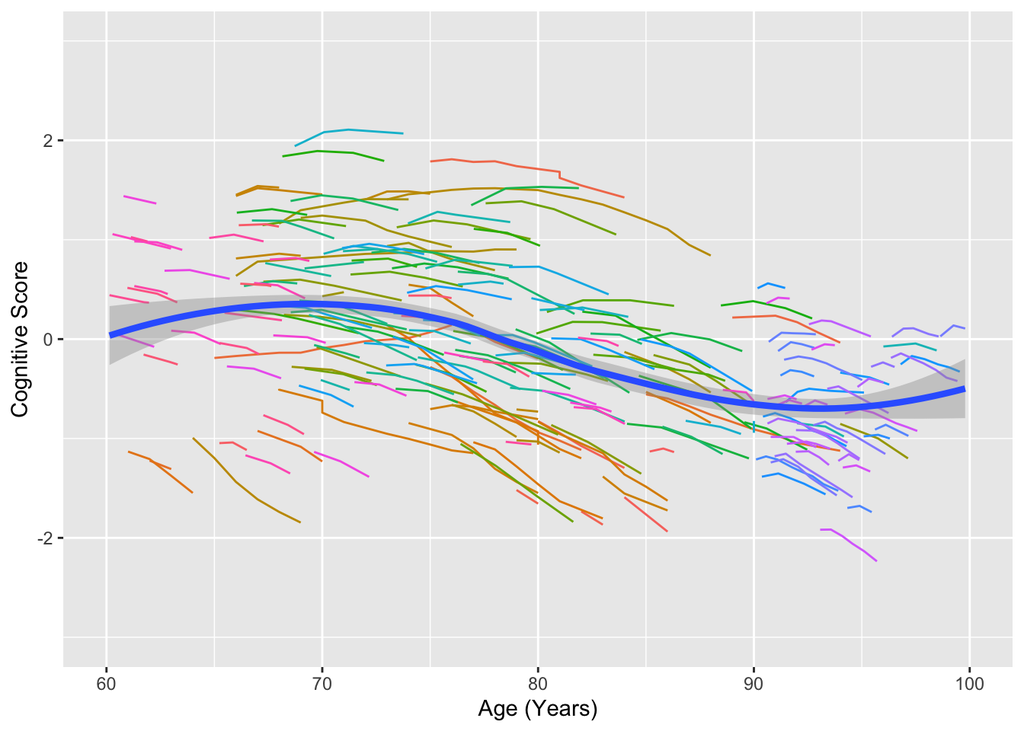

Time in study (quadratic) + baseline age (quadratic) - Bayesian quadratic mixed effects model (brms)

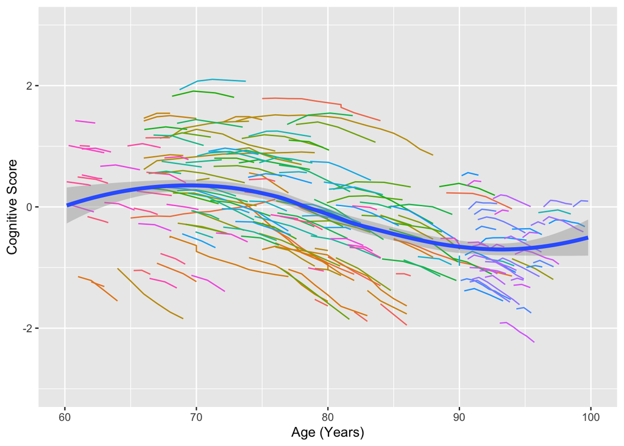

Age (quadratic) - Bayesian quadratic mixed effects model (brms)

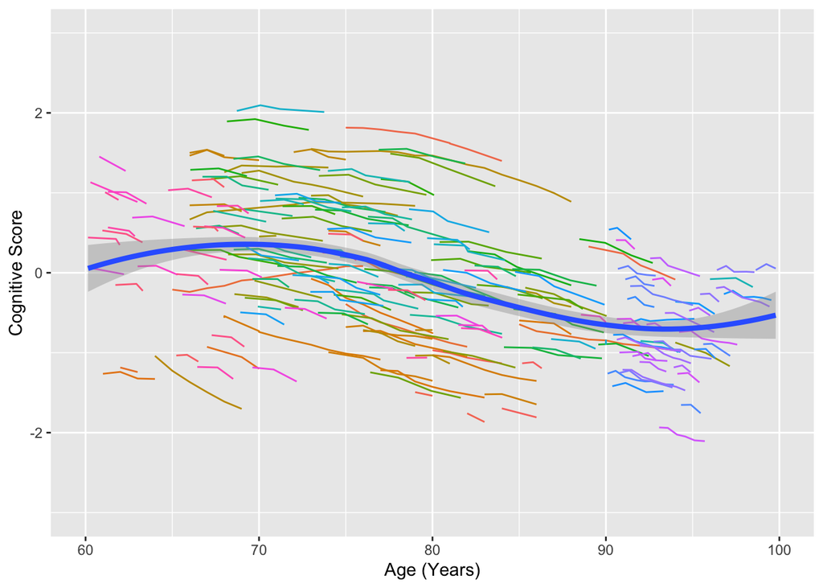

### Simulated Cognitive Trajectory Dataset Based on Empirical Model Results

```r
#   ********************** Create synthetic dataset ****************************
time <- as.numeric(rep(0:10,792))
preval1 <- as.numeric(rep(c(0,1,1,1,1,1,1,1,1,1,1),792))
preval2 <- as.numeric(rep(c(0,0,1,1,1,1,1,1,1,1,1),792))

for (i in 1:2) {
    for (j in 60:95) {
        if (i == 1 & j == 60){
            agebl <- rep(60,11)
        } else {
            agebl <- c(agebl,rep(j,11))
        }
    }
}

s4 <- data.frame(cbind(time,preval1,preval2,agebl))
s4$vrmem <- NA

for (i in 1:792){
    for (j in 1:11){
        s4[(i-1)*11 + j,"id"] <- i
    }
}

s4 <- s4 %>% mutate(
    agebl_75 = agebl - 75,
    age = agebl + time
)

### polynomial decomposition of systhetic data time variable
#   poly is model object for time orthogonal polynomial decomposition in
#    empirical dataset (df1)
poly <- poly(df1$time,degree=2)
# apply poly to s4 dataset to generate linear (timep1) and quadratic (timep2) components
s4 <- s4 %>% bind_cols(predict(poly,s4$time)) %>% rename(timep1 = `1`,timep2 = `2`)
# rescale timep1 and timep1 to have standard deviations corresponding to those
#   of the empirical time metric
s4 <- s4 %>% mutate(
    timep1s = (((timep1 - mean(df$timep1)) / sd(df$timep1)) * sd(df1$time)),
    timep2s = (((timep2 - mean(df$timep2)) / sd(df$timep2)) * sd(df1$time^2))
)
rm(poly)
### end polynomial decomposition of synthetic dataset

### generate simulated vrmem outcomes corresponding to synthetic data
#   fit_vm_poly_pr_age_brms is empirical model object
#   simulated outcome is taken from posterior probability draws from the Bayesian model
#   sample_new_levels = "old_levels" randomly samples random effects values from empirical model
pp2 <- posterior_predict(fit_vm_poly_pr_age_brms, newdata = s4,
    allow_new_levels = TRUE, sample_new_levels = "old_levels")
pp2 <- data.frame(t(pp2))
names(pp2) <- paste0("vm",1:4000)
pp2$vm_pred <- apply(pp2,1,function(x) mean(x))
#  pp2 is dataframe with 4000 simulated vrmem variables (vm1-vm4000) and the mean of
#   the 4000 simulations (vm_pred)

s4 <- s4 %>% bind_cols(pp2)
rm(pp2)
### end generate simulated vrmem outcomes

# ---------------------------- End synthetic dataset ---------------------------
```

Empirical model formula applied to simulated dataset for 1 simulated outcome (vm15)

```r
# summary(s4$vm_pred)

# fit_vm_poly_pr_age_sim <- lmer(vm_pred ~ poly(time,degree=2) + preval1 + preval2 +
#     agebl_75 + poly(time,degree=2):agebl_75 + (1 + poly(time,degree=2) | id), data=s4)
# fit_vm_poly_pr_age_sim_15 <- lmer(vm15 ~ timep1s + timep2s + preval1 + preval2 +
#     agebl_75 + timep1s:agebl_75 + timep2s:agebl_75 + (1 + timep1s + timep2s | id), data=s4)
# summary(fit_vm_poly_pr_age_sim_15)
#

# frml <- "vm_pred ~ timep1s + timep2s + preval1 + preval2 +
#     agebl_75 + timep1s:agebl_75 + timep2s:agebl_75 + (1 + timep1s + timep2s | id)"
# fit_vm_poly_pr_age_sim_brms_avg <- brm(frml, data=s4, chains = 4, cores = 4)
# print(fit_vm_poly_pr_age_sim_brms_avg,digits=4)
# # print(fit_vm_poly_pr_age_brms,digits=4)

### This model applies the model formula from the empirical model to the simulated dataset
#       for one arbitrarily chosen simulated outcome (vm15)
#       (model run in advance and model object saved)
# frml <- "vm15 ~ timep1s + timep2s + preval1 + preval2 +
#     agebl_75 + timep1s:agebl_75 + timep2s:agebl_75 + (1 + timep1s + timep2s | id)"
# fit_vm_poly_pr_age_sim_brms_15 <- brm(frml, data=s4, chains = 4, cores = 4)
print(fit_vm_poly_pr_age_sim_brms_15,digits=4)
```

```
##  Family: gaussian
##   Links: mu = identity; sigma = identity
## Formula: vm15 ~ timep1s + timep2s + preval1 + preval2 + agebl_75 + timep1s:agebl_75 + timep2s:agebl_75 + (1 + timep1s + timep2s | id)
##    Data: s4 (Number of observations: 8712)
##   Draws: 4 chains, each with iter = 2000; warmup = 1000; thin = 1;
##          total post-warmup draws = 4000
##
## Group-Level Effects:
## ~id (Number of levels: 792)
##                        Estimate Est.Error l-95% CI u-95% CI   Rhat Bulk_ESS
## sd(Intercept)            0.7481    0.0207   0.7080   0.7880 1.0049      974
## sd(timep1s)              0.0584    0.0026   0.0534   0.0637 1.0011     2416
## sd(timep2s)              0.0018    0.0005   0.0010   0.0028 1.0049      970
## cor(Intercept,timep1s)   0.1375    0.0492   0.0422   0.2346 1.0007     3068
## cor(Intercept,timep2s)  -0.5812    0.1638  -0.8854  -0.2684 1.0048     1345
## cor(timep1s,timep2s)    -0.5055    0.1916  -0.8434  -0.1200 1.0014     1769
##                        Tail_ESS
## sd(Intercept)              1347
## sd(timep1s)                2849
## sd(timep2s)                1825
## cor(Intercept,timep1s)     3245
## cor(Intercept,timep2s)     2677
## cor(timep1s,timep2s)       3229
##
## Population-Level Effects:
##                  Estimate Est.Error l-95% CI u-95% CI   Rhat Bulk_ESS Tail_ESS
## Intercept         -0.1587    0.0372  -0.2328  -0.0864 1.0041     1109     1885
## timep1s           -0.0877    0.0033  -0.0942  -0.0812 1.0001     5517     3147
## timep2s           -0.0010    0.0005  -0.0019  -0.0001 1.0001     5728     3498
## preval1            0.0210    0.0284  -0.0354   0.0764 1.0020     9172     2703
## preval2            0.0418    0.0297  -0.0151   0.0992 1.0035    10000     2601
## agebl_75          -0.0451    0.0028  -0.0505  -0.0395 1.0073      565     1316
## timep1s:agebl_75  -0.0032    0.0003  -0.0038  -0.0027 1.0012     4788     3574
## timep2s:agebl_75  -0.0001    0.0000  -0.0002  -0.0001 1.0003     3239     2968
##
## Family Specific Parameters:
##       Estimate Est.Error l-95% CI u-95% CI   Rhat Bulk_ESS Tail_ESS
## sigma   0.5125    0.0043   0.5040   0.5208 1.0004     3502     2798
##
## Draws were sampled using sampling(NUTS). For each parameter, Bulk_ESS
## and Tail_ESS are effective sample size measures, and Rhat is the potential
## scale reduction factor on split chains (at convergence, Rhat = 1).
```

```r
### This model applies the model formula from the empirical model to mean
#       of the 4000 simulations. Note that estimated erro variance becomes very small
# frml <- "vm_pred ~ poly(time,degree=2) + preval1 + preval2 +
#     + agebl_75 + poly(time,degree=2):agebl_75 + (1 + poly(time,degree=2) | id)"
# fit_vm_poly_pr_age_sim_brm <- brm(frml, data=s4, chains = 4, cores = 4)
# fit_vm_poly_pr_age_sim_brm
```

### Model Predicted Trajectories - Simulated Data (200 randomly selected persons)

This figure plots the mean of simulated cognitive trajectories against age.

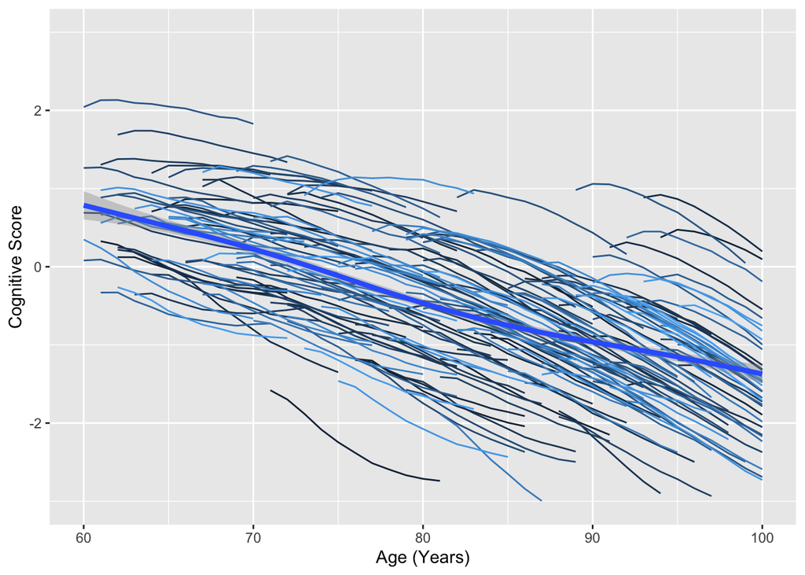

## Wrap-up

- This shows one method for generating simulated true cognitive trajectories based on real world empirical data
  - Results show that the the original empirical model can be reasonably reproduced in a fully systhetic dataset
  - Simulated cognitive trajectories show pattern of variability similar to what was observed in empirical data
  - The simulated dataset is based on 2 primary parameters - baseline age and time in study
    - Age and time values chosen for this synthetic dataset were arbitrary, different distributions of age and time could be created
- Next steps
  - Use the simulated “true” cognitive values from this methods to generate simulated observed cognitive responses using simulate_fscores() (with some modifications)